# PW3

2022-09-29

# **PW3**

# **Multiple Linear Regression**

Question 1

```r
library(MASS)

dim(Boston)
```

```
## [1] 506  14
```

```r
summary(Boston)
```

```
##       crim                zn             indus            chas
##  Min.   : 0.00632   Min.   :  0.00   Min.   : 0.46   Min.   :0.00000
##  1st Qu.: 0.08205   1st Qu.:  0.00   1st Qu.: 5.19   1st Qu.:0.00000
##  Median : 0.25651   Median :  0.00   Median : 9.69   Median :0.00000
##  Mean   : 3.61352   Mean   : 11.36   Mean   :11.14   Mean   :0.06917
##  3rd Qu.: 3.67708   3rd Qu.: 12.50   3rd Qu.:18.10   3rd Qu.:0.00000
##  Max.   :88.97620   Max.   :100.00   Max.   :27.74   Max.   :1.00000
##       nox               rm             age              dis
##  Min.   :0.3850   Min.   :3.561   Min.   :  2.90   Min.   : 1.130
##  1st Qu.:0.4490   1st Qu.:5.886   1st Qu.: 45.02   1st Qu.: 2.100
##  Median :0.5380   Median :6.208   Median : 77.50   Median : 3.207
##  Mean   :0.5547   Mean   :6.285   Mean   : 68.57   Mean   : 3.795
##  3rd Qu.:0.6240   3rd Qu.:6.623   3rd Qu.: 94.08   3rd Qu.: 5.188
##  Max.   :0.8710   Max.   :8.780   Max.   :100.00   Max.   :12.127
##       rad              tax           ptratio          black
##  Min.   : 1.000   Min.   :187.0   Min.   :12.60   Min.   :  0.32
##  1st Qu.: 4.000   1st Qu.:279.0   1st Qu.:17.40   1st Qu.:375.38
##  Median : 5.000   Median :330.0   Median :19.05   Median :391.44
##  Mean   : 9.549   Mean   :408.2   Mean   :18.46   Mean   :356.67
##  3rd Qu.:24.000   3rd Qu.:666.0   3rd Qu.:20.20   3rd Qu.:396.23
##  Max.   :24.000   Max.   :711.0   Max.   :22.00   Max.   :396.90
##      lstat            medv
##  Min.   : 1.73   Min.   : 5.00
##  1st Qu.: 6.95   1st Qu.:17.02
##  Median :11.36   Median :21.20
##  Mean   :12.65   Mean   :22.53
##  3rd Qu.:16.95   3rd Qu.:25.00
##  Max.   :37.97   Max.   :50.00
```

```r
View(Boston)
```

Question 2

```r
train= 1:round(dim(Boston)[1]*0.8, digits=0)

test= -train

training_set= Boston[train,]

test_set= Boston[test,]

View(training_set)
View(test_set)
```

Compute the 80% of the length of the Boston dataset and split it with this ratio (80% for train_set and 20% for the test_set)

Question 3

```r
cor(x = training_set$medv, y= training_set$age)
```

```
## [1] -0.2942173
```

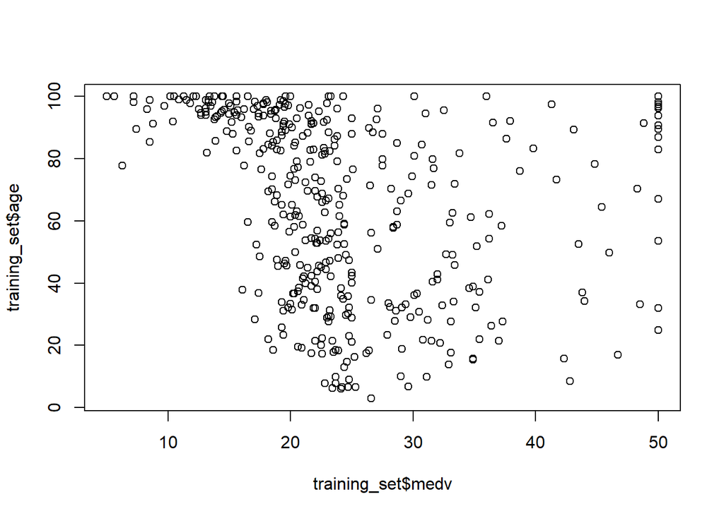

```r
plot(training_set$medv, training_set$age)
```

We can see a correlation coefficient of -0.29. So we can conclude that there is no linearity between the variables ‘medv’ and ‘age’. Moreover, the plot confirms it, graphically, we can’t see any linearity

Question 4

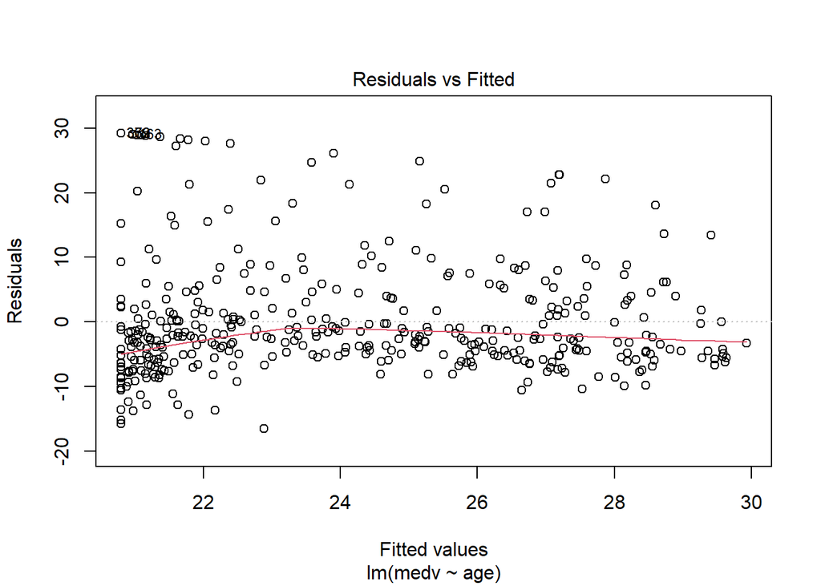

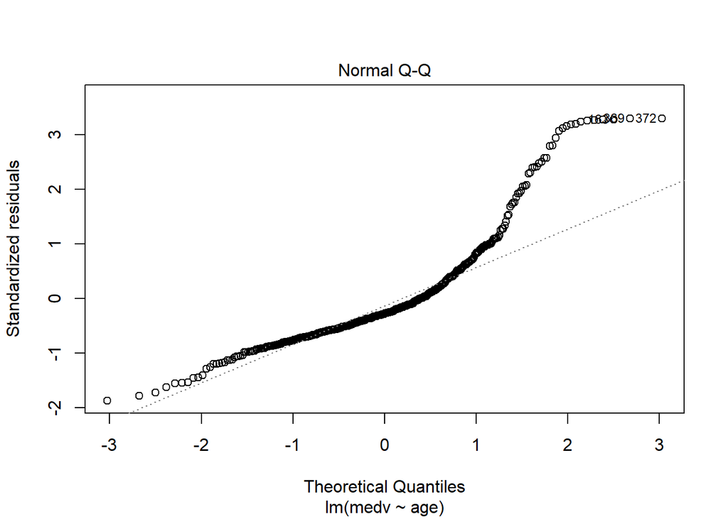

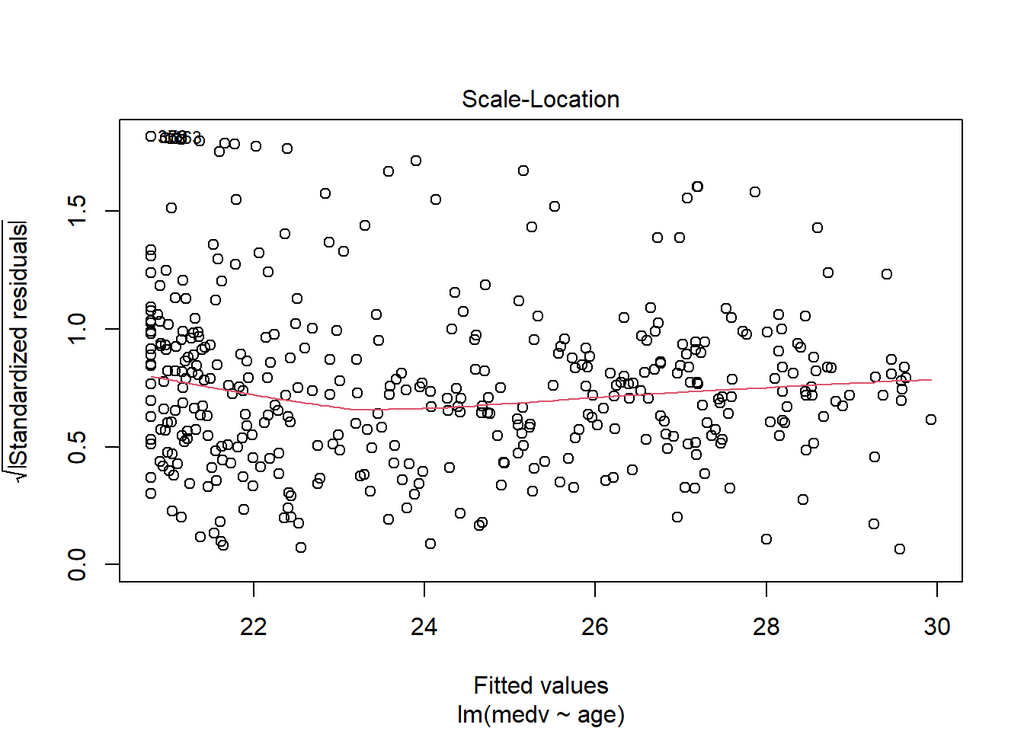

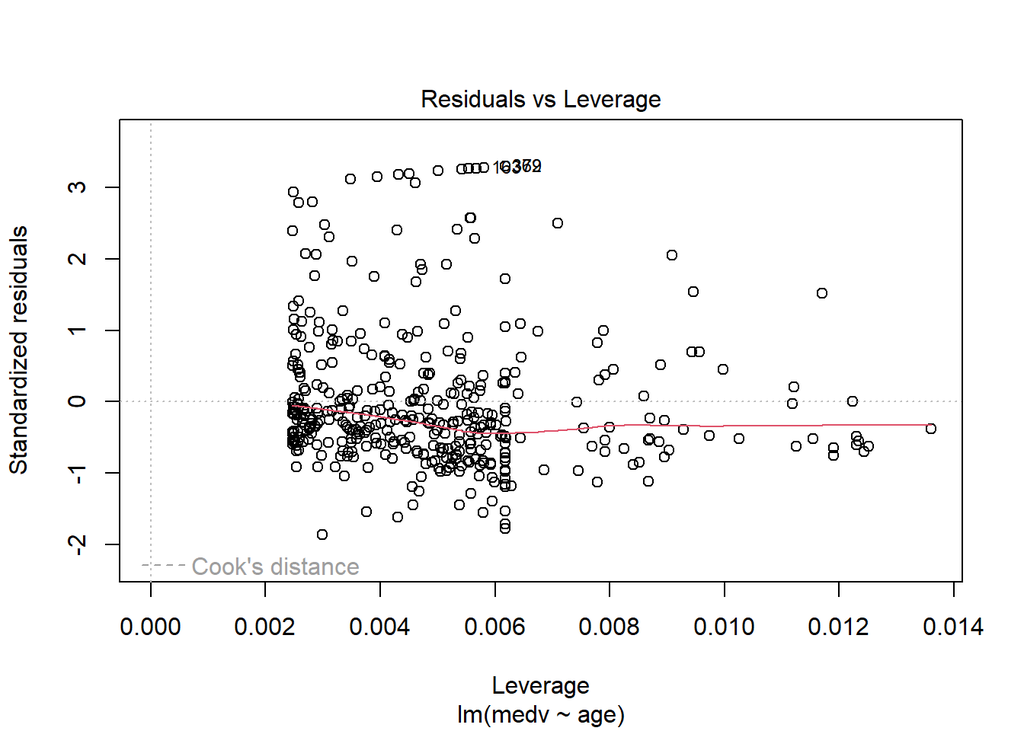

```r
lm <- lm(medv~age, data= training_set)

plot(lm)
```

We can see on the Residuals vs Fitted and the Scale location plots that there is no linearity between the median value of the owner-occupied homes and the age of population. With the Normal Q-Q diagram, we can conclude that the model is not relevant for this data. There are not any influential points in our regression model.

Question 5 & 6

```r
training_set$lstat= log(training_set$lstat)

model1 <- lm(medv~lstat+age, data= training_set)

summary(model1)
```

```
##
## Call:
## lm(formula = medv ~ lstat + age, data = training_set)
##
## Residuals:
##      Min       1Q   Median       3Q      Max
## -13.5273  -3.4091  -0.9084   2.7119  23.0669
##
## Coefficients:
##              Estimate Std. Error t value Pr(>|t|)
## (Intercept)  51.91794    1.03044  50.384  < 2e-16 ***
## lstat       -14.47257    0.53671 -26.965  < 2e-16 ***
## age           0.07643    0.01107   6.901 2.01e-11 ***
## ---
## Signif. codes:  0 '***' 0.001 '**' 0.01 '*' 0.05 '.' 0.1 ' ' 1
##
## Residual standard error: 5.307 on 402 degrees of freedom
## Multiple R-squared:  0.6748, Adjusted R-squared:  0.6732
## F-statistic: 417.1 on 2 and 402 DF,  p-value: < 2.2e-16
```

Question 7

According to the Signif. codes (***), the predictors are significant.

Question 8

Question 9

```r
model2 <- lm(medv~., data= training_set)
summary(model2)
```

```
##
## Call:
## lm(formula = medv ~ ., data = training_set)
##
## Residuals:
##      Min       1Q   Median       3Q      Max
## -17.7169  -2.7380  -0.2591   1.8459  24.0501
##
## Coefficients:
##               Estimate Std. Error t value Pr(>|t|)
## (Intercept)  50.480161   5.910736   8.540 3.01e-16 ***
## crim         -0.183211   0.045684  -4.010 7.26e-05 ***
## zn            0.025920   0.012789   2.027 0.043372 *
## indus         0.030698   0.059151   0.519 0.604072
## chas          1.687863   0.806374   2.093 0.036980 *
## nox         -13.950944   4.127556  -3.380 0.000798 ***
## rm            3.187884   0.461970   6.901 2.10e-11 ***
## age           0.030989   0.013238   2.341 0.019740 *
## dis          -1.111061   0.192674  -5.767 1.65e-08 ***
## rad           0.396386   0.079004   5.017 7.97e-07 ***
## tax          -0.014690   0.004025  -3.650 0.000298 ***
## ptratio      -0.736914   0.127126  -5.797 1.39e-08 ***
## black        -0.002201   0.005895  -0.373 0.709106
## lstat        -8.980107   0.646947 -13.881  < 2e-16 ***
## ---
## Signif. codes:  0 '***' 0.001 '**' 0.01 '*' 0.05 '.' 0.1 ' ' 1
##
## Residual standard error: 4.356 on 391 degrees of freedom
## Multiple R-squared:  0.7869, Adjusted R-squared:  0.7798
## F-statistic:   111 on 13 and 391 DF,  p-value: < 2.2e-16
```

Question 10

```r
training_set$lstat= log(training_set$lstat)
model3 <- lm(medv~., data= training_set)
summary(model3)
```

```
##
## Call:
## lm(formula = medv ~ ., data = training_set)
##
## Residuals:
##      Min       1Q   Median       3Q      Max
## -16.6928  -2.4581  -0.3465   1.8267  25.6071
##
## Coefficients:
##               Estimate Std. Error t value Pr(>|t|)
## (Intercept)  43.765471   5.667843   7.722 9.72e-14 ***
## crim         -0.215118   0.044861  -4.795 2.31e-06 ***
## zn            0.016893   0.012735   1.326 0.185455
## indus        -0.017517   0.058613  -0.299 0.765201
## chas          1.551067   0.800042   1.939 0.053253 .
## nox         -13.932216   4.092502  -3.404 0.000732 ***
## rm            3.345865   0.448286   7.464 5.51e-13 ***
## age           0.020798   0.012817   1.623 0.105462
## dis          -1.081272   0.191244  -5.654 3.03e-08 ***
## rad           0.392801   0.078350   5.013 8.12e-07 ***
## tax          -0.014240   0.003991  -3.568 0.000404 ***
## ptratio      -0.731730   0.126070  -5.804 1.34e-08 ***
## black        -0.003281   0.005842  -0.562 0.574671
## lstat       -17.041085   1.197115 -14.235  < 2e-16 ***
## ---
## Signif. codes:  0 '***' 0.001 '**' 0.01 '*' 0.05 '.' 0.1 ' ' 1
##
## Residual standard error: 4.319 on 391 degrees of freedom
## Multiple R-squared:  0.7904, Adjusted R-squared:  0.7835
## F-statistic: 113.4 on 13 and 391 DF,  p-value: < 2.2e-16
```

Question 11

Question 12

```r
Q <- round(cor(training_set, training_set), digits= 2)
Q
```

```
##          crim    zn indus  chas   nox    rm   age   dis   rad   tax ptratio
## crim     1.00 -0.17  0.37 -0.01  0.40 -0.18  0.30 -0.34  0.65  0.60    0.22
## zn      -0.17  1.00 -0.51 -0.08 -0.49  0.31 -0.56  0.64 -0.24 -0.23   -0.33
## indus    0.37 -0.51  1.00  0.15  0.75 -0.41  0.62 -0.68  0.48  0.60    0.25
## chas    -0.01 -0.08  0.15  1.00  0.16  0.08  0.14 -0.16  0.12  0.08   -0.07
## nox      0.40 -0.49  0.75  0.16  1.00 -0.32  0.72 -0.76  0.55  0.62    0.04
## rm      -0.18  0.31 -0.41  0.08 -0.32  1.00 -0.24  0.17 -0.23 -0.31   -0.36
## age      0.30 -0.56  0.62  0.14  0.72 -0.24  1.00 -0.73  0.40  0.45    0.17
## dis     -0.34  0.64 -0.68 -0.16 -0.76  0.17 -0.73  1.00 -0.44 -0.46   -0.11
## rad      0.65 -0.24  0.48  0.12  0.55 -0.23  0.40 -0.44  1.00  0.88    0.35
## tax      0.60 -0.23  0.60  0.08  0.62 -0.31  0.45 -0.46  0.88  1.00    0.32
## ptratio  0.22 -0.33  0.25 -0.07  0.04 -0.36  0.17 -0.11  0.35  0.32    1.00
## black   -0.06  0.13 -0.27 -0.05 -0.35  0.20 -0.21  0.20 -0.06 -0.16    0.08
## lstat    0.28 -0.44  0.46 -0.05  0.45 -0.69  0.51 -0.35  0.27  0.34    0.33
## medv    -0.31  0.31 -0.39  0.14 -0.32  0.75 -0.29  0.13 -0.24 -0.34   -0.45
##         black lstat  medv
## crim    -0.06  0.28 -0.31
## zn       0.13 -0.44  0.31
## indus   -0.27  0.46 -0.39
## chas    -0.05 -0.05  0.14
## nox     -0.35  0.45 -0.32
## rm       0.20 -0.69  0.75
## age     -0.21  0.51 -0.29
## dis      0.20 -0.35  0.13
## rad     -0.06  0.27 -0.24
## tax     -0.16  0.34 -0.34
## ptratio  0.08  0.33 -0.45
## black    1.00 -0.17  0.14
## lstat   -0.17  1.00 -0.80
## medv     0.14 -0.80  1.00
```

```r
for (i in 1:dim(Q)[1]) {
  for (j in 1:dim(Q)[2]) {
    if(Q[i,j] > 0.8 && rownames(Q)[i] != colnames(Q)[j])
    {
      ch <- paste(rownames(Q)[i], " and ", colnames(Q)[j], "are correlated: ", Q[i,j])
      print(ch)
    }
  }
}
```

```
## [1] "rad  and  tax are correlated:  0.88"
## [1] "tax  and  rad are correlated:  0.88"
```

So we can see that there are some correlations between the variables.

Question 13

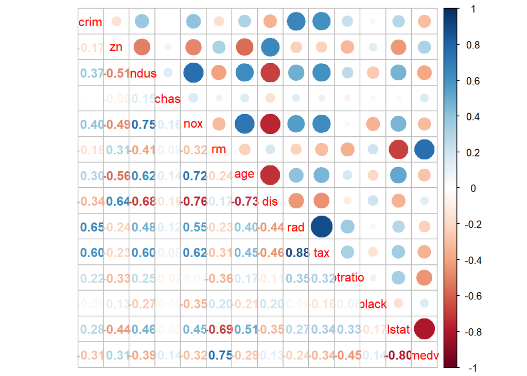

```r
library(corrplot)
corrplot.mixed(Q)
```

As we saw before, there are some correlations between some variabes.

Question 14

```r
for (i in 1:dim(Q)[1]) {
  for (j in 1:dim(Q)[2]) {
    if(rownames(Q)[i] == "tax" && colnames(Q)[j] == "rad")
    {
      ch <- paste(rownames(Q)[i], " and ", colnames(Q)[j], "are correlated: ", Q[i,j])
      print(ch)
    }
  }
}
```

```
## [1] "tax  and  rad are correlated:  0.88"
```

As we seen before, we can see a strong correlation between tax and rad.

Question 15

```r
model4 <- lm(medv~.-tax, data= training_set)
summary(model4)
```

```
##
## Call:
## lm(formula = medv ~ . - tax, data = training_set)
##
## Residuals:
##      Min       1Q   Median       3Q      Max
## -17.2455  -2.5356  -0.2465   1.7795  25.4218
##
## Coefficients:
##               Estimate Std. Error t value Pr(>|t|)
## (Intercept)  41.369942   5.711556   7.243 2.34e-12 ***
## crim         -0.220236   0.045505  -4.840 1.87e-06 ***
## zn            0.007572   0.012650   0.599 0.549811
## indus        -0.080443   0.056728  -1.418 0.156972
## chas          1.843850   0.807646   2.283 0.022965 *
## nox         -15.855469   4.117127  -3.851 0.000137 ***
## rm            3.441319   0.454135   7.578 2.56e-13 ***
## age           0.019391   0.013001   1.492 0.136626
## dis          -1.116190   0.193831  -5.759 1.72e-08 ***
## rad           0.185244   0.053273   3.477 0.000563 ***
## ptratio      -0.760095   0.127688  -5.953 5.86e-09 ***
## black        -0.001619   0.005909  -0.274 0.784243
## lstat       -17.003436   1.214852 -13.996  < 2e-16 ***
## ---
## Signif. codes:  0 '***' 0.001 '**' 0.01 '*' 0.05 '.' 0.1 ' ' 1
##
## Residual standard error: 4.383 on 392 degrees of freedom
## Multiple R-squared:  0.7836, Adjusted R-squared:  0.777
## F-statistic: 118.3 on 12 and 392 DF,  p-value: < 2.2e-16
```

Question 16

```r
MSE <- mean(summary(model4)$residuals^2)
MSE
```

```
## [1] 18.59819
```

The lower the value for MSE, the more accurately a model is able to predict values.

Question 17

```r
str(training_set$chas)
```

```
##  int [1:405] 0 0 0 0 0 0 0 0 0 0 ...
```

```r
table(training_set$chas)
```

```
##
##   0   1
## 370  35
```

We can see that there is 35 suburbs in this data set which bound the Charles river.

Question 18

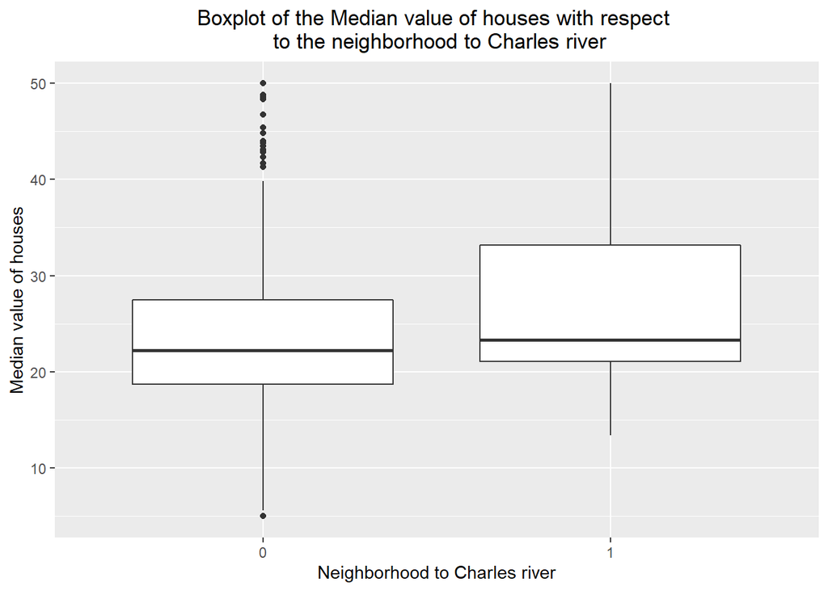

```r
library(ggplot2)
colors= c("blue", "cyan4")

ggplot(training_set, aes(x= as.factor(chas), y= medv)) +
  geom_boxplot() +
  ggtitle("Boxplot of the Median value of houses with respect \n to the neighborhood to Charles river") +
  theme(plot.title = element_text(hjust = 0.5)) +
  labs(x= "Neighborhood to Charles river", y= "Median value of houses" )
```

We can see that the medians are almost equal. However, there is more variance in prices if they are in the suburbs along the Charles River.

Question 19

```r
aggregate(medv~chas, data= training_set, mean)
```

```
##   chas  medv
## 1    0 23.73
## 2    1 28.44
```

This function computes the average of ‘chas’ variable. The average price of a suburban home not bordering the Charles River is: 23.73. The average house price in the Charles River suburb is: 28.44.

Question 20

```r
ANOVAtest <- aov(medv~chas, training_set)
ANOVAtest
```

```
## Call:
##    aov(formula = medv ~ chas, data = training_set)
##
## Terms:
##                     chas Residuals
## Sum of Squares    709.34  34099.76
## Deg. of Freedom        1       403
##
## Residual standard error: 9.19863
## Estimated effects may be unbalanced
```

```r
summary(ANOVAtest)
```

```
##              Df Sum Sq Mean Sq F value  Pr(>F)
## chas          1    709   709.3   8.383 0.00399 **
## Residuals   403  34100    84.6
## ---
## Signif. codes:  0 '***' 0.001 '**' 0.01 '*' 0.05 '.' 0.1 ' ' 1
```

We can see a p-value of 0.00399 (which is very low), which means that our model is significant. So, the variable ‘chas’ is significant: there is a significant difference of price between a housing in suburbs along the Charles river and another.

## **Qualitative predictors**

Question 21

```r
model5 <- lm(medv~chas+crim, data= training_set)
summary(model5)
```

```
##
## Call:
## lm(formula = medv ~ chas + crim, data = training_set)
##
## Residuals:
##     Min      1Q  Median      3Q     Max
## -14.396  -5.822  -2.173   3.603  29.426
##
## Coefficients:
##             Estimate Std. Error t value Pr(>|t|)
## (Intercept) 24.61889    0.47490  51.841  < 2e-16 ***
## chas         4.63230    1.54820   2.992  0.00294 **
## crim        -0.43808    0.06685  -6.553 1.73e-10 ***
## ---
## Signif. codes:  0 '***' 0.001 '**' 0.01 '*' 0.05 '.' 0.1 ' ' 1
##
## Residual standard error: 8.754 on 402 degrees of freedom
## Multiple R-squared:  0.1149, Adjusted R-squared:  0.1105
## F-statistic:  26.1 on 2 and 402 DF,  p-value: 2.198e-11
```

In this model with the form: Y= b0 + b1 * X1 + b2 * X2, we can see that: b0= 24.61889 b1 = 4.63230 b2= -0.43808 We can see that the Pr(>|t|) of ‘chas’ is quiet low so ce can conclude that the variable ‘chas’ is significant with this model. Moreover, we can see an Adjusted R-squared of 0.1105, so 11.05% of medv can be explained with this variables.

Question 22

```r
summary(model3) #This model was fitted before (Question 10). It take account all the variables
```

```
##
## Call:
## lm(formula = medv ~ ., data = training_set)
##
## Residuals:
##      Min       1Q   Median       3Q      Max
## -16.6928  -2.4581  -0.3465   1.8267  25.6071
##
## Coefficients:
##               Estimate Std. Error t value Pr(>|t|)
## (Intercept)  43.765471   5.667843   7.722 9.72e-14 ***
## crim         -0.215118   0.044861  -4.795 2.31e-06 ***
## zn            0.016893   0.012735   1.326 0.185455
## indus        -0.017517   0.058613  -0.299 0.765201
## chas          1.551067   0.800042   1.939 0.053253 .
## nox         -13.932216   4.092502  -3.404 0.000732 ***
## rm            3.345865   0.448286   7.464 5.51e-13 ***
## age           0.020798   0.012817   1.623 0.105462
## dis          -1.081272   0.191244  -5.654 3.03e-08 ***
## rad           0.392801   0.078350   5.013 8.12e-07 ***
## tax          -0.014240   0.003991  -3.568 0.000404 ***
## ptratio      -0.731730   0.126070  -5.804 1.34e-08 ***
## black        -0.003281   0.005842  -0.562 0.574671
## lstat       -17.041085   1.197115 -14.235  < 2e-16 ***
## ---
## Signif. codes:  0 '***' 0.001 '**' 0.01 '*' 0.05 '.' 0.1 ' ' 1
##
## Residual standard error: 4.319 on 391 degrees of freedom
## Multiple R-squared:  0.7904, Adjusted R-squared:  0.7835
## F-statistic: 113.4 on 13 and 391 DF,  p-value: < 2.2e-16
```

We can see a Pr(>|t|) of 0.053253 for ‘chas’ variable. This is a high value, it means that ‘chas’ variable is not significant in this model.

## **Interaction terms**

Question 23

```r
model6 <- lm(medv~lstat*age, data= training_set)
summary(model6)
```

```
##
## Call:
## lm(formula = medv ~ lstat * age, data = training_set)
##
## Residuals:
##      Min       1Q   Median       3Q      Max
## -18.0390  -3.0657  -0.6385   2.3510  24.9789
##
## Coefficients:
##              Estimate Std. Error t value Pr(>|t|)
## (Intercept)  36.24021    1.60398  22.594  < 2e-16 ***
## lstat       -18.30760    2.40266  -7.620 1.85e-13 ***
## age           0.14720    0.02440   6.034 3.65e-09 ***
## lstat:age    -0.13601    0.03127  -4.350 1.73e-05 ***
## ---
## Signif. codes:  0 '***' 0.001 '**' 0.01 '*' 0.05 '.' 0.1 ' ' 1
##
## Residual standard error: 5.272 on 401 degrees of freedom
## Multiple R-squared:  0.6799, Adjusted R-squared:  0.6775
## F-statistic: 283.9 on 3 and 401 DF,  p-value: < 2.2e-16
```

We can see with the values of Pr(>|t|) that all the variables are significant. Moreover, we have an Adjusted R-squared value of 0.6775 which is quiet good. We can compare this value with a model without first order interaction terms. The value of the Adjusted R-squared of the model1 (Question 5) is 0.6732. So with first order interaction terms, we improved our model with the variables ‘lstat’ and ‘age’.

Question 24

```r
model7 <- lm(medv~.*., data= training_set)
summary(model7)
```

```
##
## Call:
## lm(formula = medv ~ . * ., data = training_set)
##
## Residuals:
##     Min      1Q  Median      3Q     Max
## -7.6952 -1.4014 -0.1144  1.2691 18.1867
##
## Coefficients:
##                 Estimate Std. Error t value Pr(>|t|)
## (Intercept)   -2.754e+02  9.387e+01  -2.934 0.003599 **
## crim          -2.589e+00  7.027e+00  -0.368 0.712843
## zn            -2.697e-02  5.017e-01  -0.054 0.957164
## indus          1.622e+00  1.967e+00   0.825 0.410263
## chas           3.295e+01  1.976e+01   1.668 0.096331 .
## nox            2.040e+02  8.900e+01   2.292 0.022575 *
## rm             4.728e+01  8.231e+00   5.744 2.19e-08 ***
## age            2.014e-01  3.522e-01   0.572 0.567823
## dis           -1.929e+00  6.249e+00  -0.309 0.757751
## rad            4.440e+00  3.019e+00   1.471 0.142396
## tax           -2.422e-01  1.733e-01  -1.397 0.163300
## ptratio        7.696e+00  3.174e+00   2.424 0.015897 *
## black          1.924e-01  1.632e-01   1.179 0.239213
## lstat         -6.967e-01  3.089e+01  -0.023 0.982023
## crim:zn        1.144e-01  1.760e-01   0.650 0.516105
## crim:indus    -1.759e-01  3.988e-01  -0.441 0.659529
## crim:chas      2.897e+00  5.906e-01   4.906 1.50e-06 ***
## crim:nox      -1.192e+01  3.815e+00  -3.126 0.001940 **
## crim:rm       -1.753e-01  9.195e-02  -1.906 0.057573 .
## crim:age      -3.797e-03  9.712e-03  -0.391 0.696095
## crim:dis      -4.954e-01  2.801e-01  -1.768 0.077955 .
## crim:rad      -6.769e-01  5.298e-01  -1.278 0.202315
## crim:tax       4.473e-02  3.882e-02   1.152 0.250196
## crim:ptratio   1.922e-01  3.168e-01   0.607 0.544383
## crim:black    -9.462e-04  2.299e-03  -0.412 0.680929
## crim:lstat    -1.022e+00  7.151e-01  -1.430 0.153808
## zn:indus      -2.158e-03  4.742e-03  -0.455 0.649359
## zn:chas       -1.099e-01  6.332e-02  -1.736 0.083603 .
## zn:nox         1.589e-02  4.968e-01   0.032 0.974501
## zn:rm         -9.091e-03  2.705e-02  -0.336 0.737066
```

[output cut: 53 more lines]

```
## rad:ptratio   -1.029e-01  1.003e-01  -1.025 0.305953
## rad:black     -5.998e-03  3.763e-03  -1.594 0.111923
## rad:lstat     -7.980e-01  5.392e-01  -1.480 0.139850
## tax:ptratio    4.442e-03  2.719e-03   1.634 0.103307
## tax:black      3.407e-04  2.616e-04   1.302 0.193743
## tax:lstat     -1.264e-02  3.107e-02  -0.407 0.684453
## ptratio:black -6.194e-03  3.839e-03  -1.614 0.107610
## ptratio:lstat -2.848e-01  6.725e-01  -0.423 0.672243
## black:lstat    7.609e-02  4.969e-02   1.531 0.126669
## ---
## Signif. codes:  0 '***' 0.001 '**' 0.01 '*' 0.05 '.' 0.1 ' ' 1
##
## Residual standard error: 2.703 on 313 degrees of freedom
## Multiple R-squared:  0.9343, Adjusted R-squared:  0.9152
## F-statistic:  48.9 on 91 and 313 DF,  p-value: < 2.2e-16
```